# projeto1

Bernardo

6 de setembro de 2018

Analisar as classes sociais dos cadastrados de acordo com as definições adotadas pelo IBGE:

Adotando a divisão:

classe alta - A média-alta - B média-intermediária - C média-baixa - D excluídos(Pobre) - E

```r
require(dplyr)
require(readr)
require(ggplot2)
require(pacman)


social <- read.csv2("/home/gudnunes/Área de Trabalho/MD/MD2018/dados/cadastrocivil.csv")


  manter=c();
for (atr in names(social)) {
  if (length(table(social[,atr]))>1) {
    manter<-c(manter,atr)
  }
}

social <- select(social, manter)

manter <- c( "Id_SERVIDOR_PORTAL",   "NOME", "UF_EXERCICIO",
 "DESCRICAO_CARGO", "CLASSE_CARGO",
"REFERENCIA_CARGO", "NIVEL_CARGO",
 "SIGLA_FUNCAO", "NIVEL_FUNCAO",
 "FUNCAO", "CODIGO_ATIVIDADE",
"ATIVIDADE" , "COD_UORG_LOTACAO",
 "UORG_LOTACAO", "ORG_LOTACAO" ,
"ORGSUP_LOTACAO" ,        "UORG_EXERCICIO" , "TIPO_VINCULO" ,         "JORNADA_DE_TRABALHO" ,
"DATA_INGRESSO_CARGOFUNCAO", "DATA_INGRESSO_ORGAO")

social <- social %>% select(manter) %>% filter(FUNCAO!="Sem informacao")

remuneracao <- read_csv2("/home/gudnunes/Área de Trabalho/Mineração de dados/MD2018/dados/Remuneracao.csv")
remuneracao <- remuneracao %>% select(Id_SERVIDOR_PORTAL, `REMUNERACAO BASICA BRUTA (R$)`, `REMUNERACAO APOS DEDUCOES OBRIGATORIAS (R$)`)
social<-left_join(x=social,y=remuneracao)
```

Aqui podemos ver uma média dos ganhos de todos o cadastrados, depois de deduções obrigatórias:

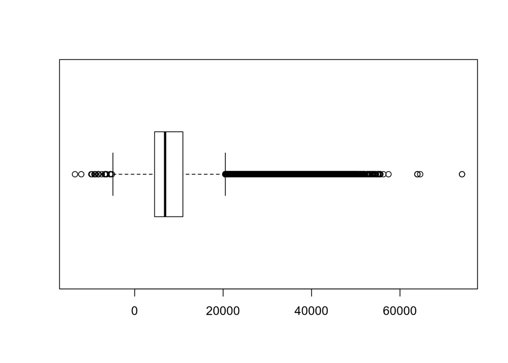

```r
social$`REMUNERACAO APOS DEDUCOES OBRIGATORIAS (R$)` <- as.double(social$`REMUNERACAO APOS DEDUCOES OBRIGATORIAS (R$)`)

boxplot(social$`REMUNERACAO APOS DEDUCOES OBRIGATORIAS (R$)`, horizontal = T)
```

Precisa criar umas condições e verificar os salários para determinar suas classes sociais: O definido pelo IBGE é: (Analisando como renda familiar)

classe alta(Rico) - A -> R$ 18.740,01 ou mais média-alta - B -> R$ 9.370,01 a R$ 18.740,00 média-intermediária - C -> R$ 3.748,01 a R$ 9.370,00 média-baixa - D -> R$ 1.874,01 a R$ 3.748,00 excluídos(Pobre) - E -> Até R$ 1.874,00

```r
social["CLASSE_SOCIAL"] <- c("i")

social$`REMUNERACAO APOS DEDUCOES OBRIGATORIAS (R$)` <- as.double(social$`REMUNERACAO APOS DEDUCOES OBRIGATORIAS (R$)`)

social <- social %>% filter(social$`REMUNERACAO APOS DEDUCOES OBRIGATORIAS (R$)` != is.na(social$`REMUNERACAO APOS DEDUCOES OBRIGATORIAS (R$)`))

social$CLASSE_SOCIAL[social$`REMUNERACAO APOS DEDUCOES OBRIGATORIAS (R$)` <= 1874] <- "Pobre"
social$CLASSE_SOCIAL[social$`REMUNERACAO APOS DEDUCOES OBRIGATORIAS (R$)` > 1874 & social$`REMUNERACAO APOS DEDUCOES OBRIGATORIAS (R$)` <= 3748] <- "Media-baixa"
social$CLASSE_SOCIAL[social$`REMUNERACAO APOS DEDUCOES OBRIGATORIAS (R$)` > 3748 & social$`REMUNERACAO APOS DEDUCOES OBRIGATORIAS (R$)` <= 9370] <- "Media-intermediaria"
social$CLASSE_SOCIAL[social$`REMUNERACAO APOS DEDUCOES OBRIGATORIAS (R$)` > 9370 & social$`REMUNERACAO APOS DEDUCOES OBRIGATORIAS (R$)` <= 18740] <- "Media-alta"
social$CLASSE_SOCIAL[social$`REMUNERACAO APOS DEDUCOES OBRIGATORIAS (R$)` > 18740
] <- "Rico"
```

Aqui podemos ver a quantidade de cada classe social no Brasil: - Grande quantidade de Média-intermediaria

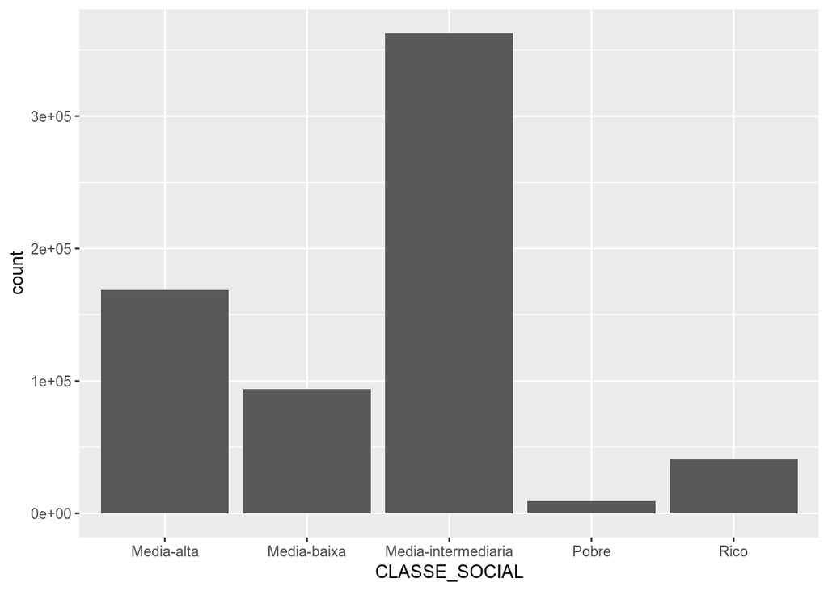

```r
attach(social)
ggplot(data=social)+geom_bar(mapping=aes(x=CLASSE_SOCIAL))
```

Agora podemos ver a quantidade de cada classe social nos estados brasileiros. Podemos notar que o sudeste é onde tem a maior quantidade de ricos, junto a Brasília e RS.

```r
social1 <- filter(social, social$UF_EXERCICIO != -1)
attach(social1)
```

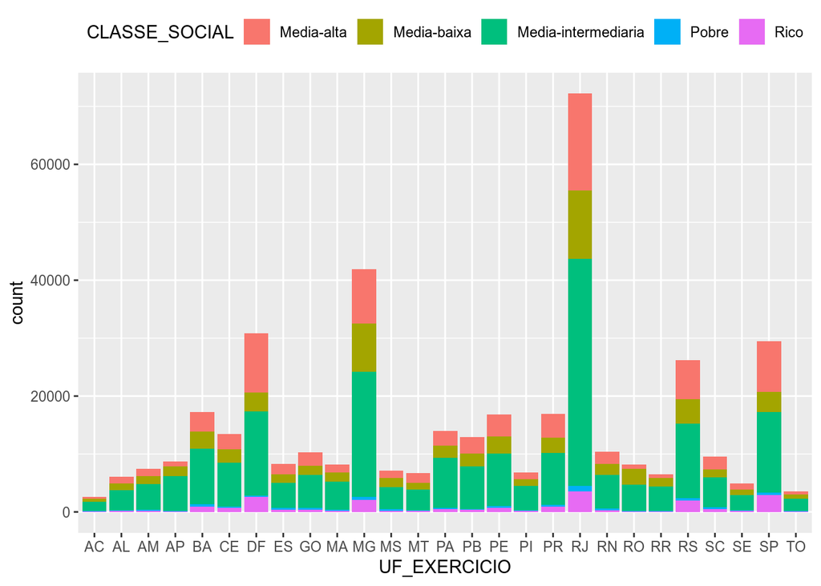

```r
ggplot(data=social1)+geom_bar(mapping=aes(x=UF_EXERCICIO, fill = CLASSE_SOCIAL))+theme(legend.position = 'top')
```

Como essas análises já estavam faceis de ser colocadas, os valores das classes sociais já estavam pre definidas pelo IBGE, não precisei fazer nenhuma Predição. Aqui está o que poderia ser predicto:

- QUAL O SALÁRIO DE UMA PESSOA, APENAS COM OUTROS DADOS, COMO:

-ESTADO -CARGO -ORGÃO -FUNÇÃO -ATIVIDADE -ANO DE ENTRADA -JORNADA DE TRABALHO